# Analysis Assignment 1

Carole Voulgaris

2023-10-30

# Input data

I am generating a simulated dataset representing housing costs. In this simulation, the monthly rent for a home is purely a function of the home’s square footage, its distance to downtown, its color, and whether it has a pool.

I’ll start by defining the input variables I’m using to generate the data.

```r
library(tidyverse)

uniform1 <- runif(10000)
uniform2 <- runif(10000)

dt_dist_mean = 4.2
dt_dist_sd = 0.7

sq_feet_mean = 1500
sq_feet_sd = 150

pct_red = 0.2
pct_blue = 0.65
pct_green = 0.15

pct_pool = 0.15
pct_no_pool = 0.85

input_coeffs = list(Constant = 100,
                    `Effect of square feet` = 0.7,
                    `Effect of distance` = -50,
                    `Effect of blue` = 100,
                    `Effect of green` = 150,
                    `Effect of pool` = 200)
```

# Data generation

Now I will generate my simulated data set.

```r
data <- tibble(sq_feet = rnorm(10000,
                               mean = sq_feet_mean,
                               sd = sq_feet_sd),
               dt_dist = rnorm(10000,
                               mean = dt_dist_mean,
                               sd = dt_dist_sd)) |>
  mutate(color = case_when(uniform1 < pct_red ~ "Red",
                           uniform1 < pct_red + pct_blue ~ "Blue",
                           TRUE ~ "Green"),
         pool = ifelse(uniform2 < pct_pool, 1, 0)) |>
  mutate(blue = ifelse(color == "Blue", 1, 0),
         green = ifelse(color == "Green", 1, 0)) |>
  mutate(rent = input_coeffs$Constant +
                input_coeffs$`Effect of square feet` * sq_feet +
                input_coeffs$`Effect of distance` * dt_dist +
                input_coeffs$`Effect of blue` * blue +
                input_coeffs$`Effect of green` * green +
                input_coeffs$`Effect of pool` * pool)
```

# Data visualization

Here are some graphs illustrating the data set.

## Distibution of continuous variables

The following histograms illustrate the distribution of each continuous variable.

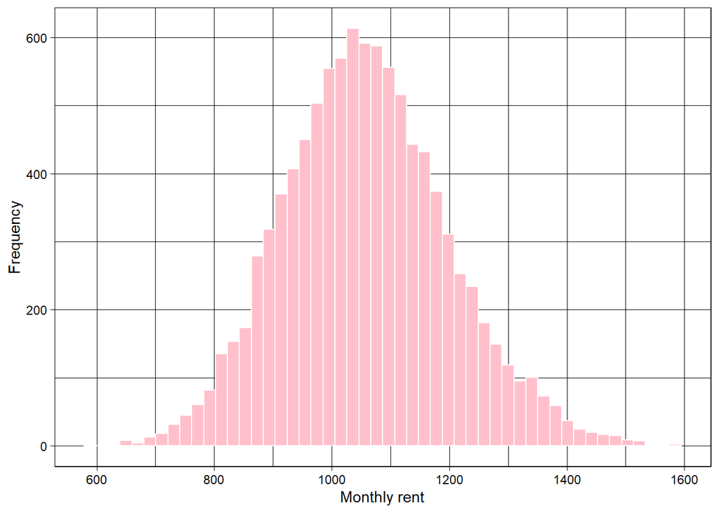

```r
ggplot(data) +
  geom_histogram(aes(x = rent),
                 bins = 50,
                 fill = "pink",
                 color = "white") +
  scale_x_continuous(name = "Monthly rent") +
  scale_y_continuous(name = "Frequency") +
  theme_linedraw()
```

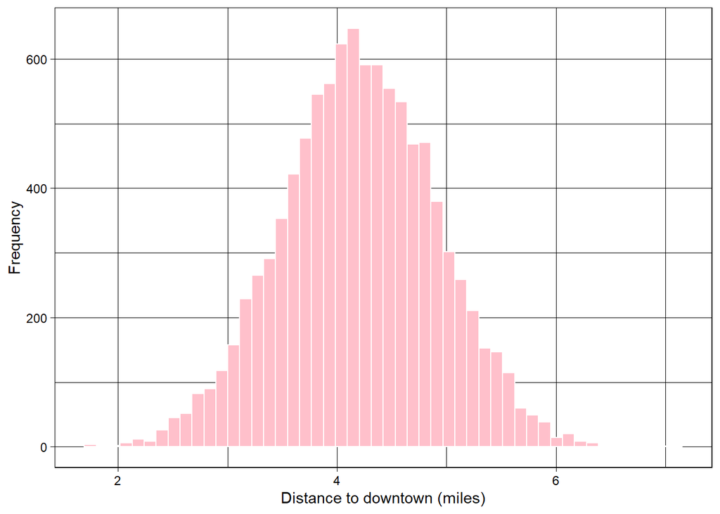

```r
ggplot(data) +
  geom_histogram(aes(x = dt_dist),
                 bins = 50,
                 fill = "pink",
                 color = "white") +
  scale_x_continuous(name = "Distance to downtown (miles)") +
  scale_y_continuous(name = "Frequency") +
  theme_linedraw()
```

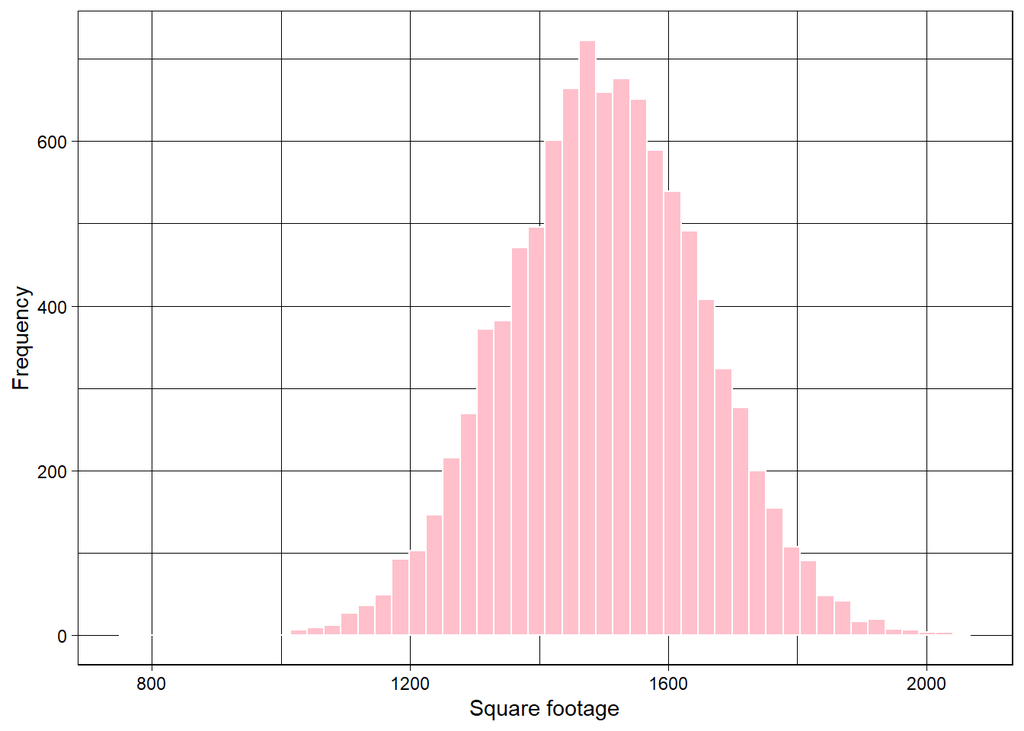

```r
ggplot(data) +
  geom_histogram(aes(x = sq_feet),
                 bins = 50,
                 fill = "pink",
                 color = "white") +
  scale_x_continuous(name = "Square footage") +
  scale_y_continuous(name = "Frequency") +
  theme_linedraw()
```

## Relationships of continuous variables with outcome

The following scatterplots illustrate the relationships between each continuous predictor variable and monthly rent.

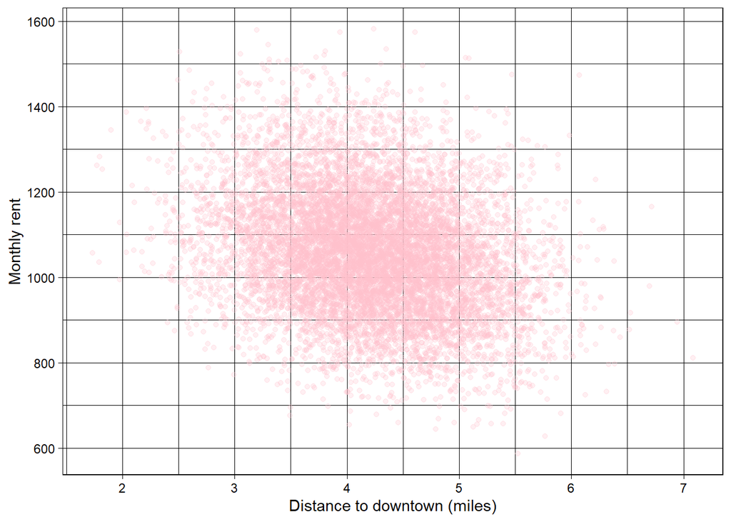

```r
ggplot(data) +
  geom_point(aes(x = dt_dist,
                 y = rent),
                 color = "pink",
                 alpha = 0.25) +
  scale_x_continuous(name = "Distance to downtown (miles)") +
  scale_y_continuous(name = "Monthly rent") +
  theme_linedraw()
```

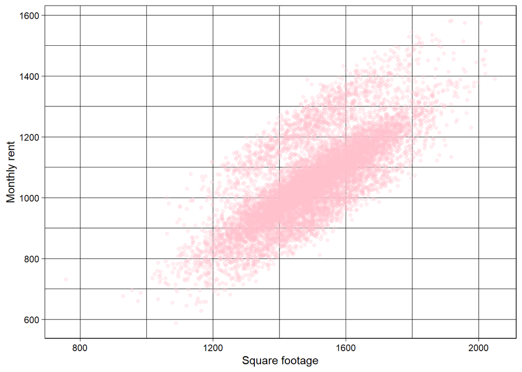

```r
ggplot(data) +
  geom_point(aes(x = sq_feet,
                 y = rent),
                 color = "pink",
                 alpha = 0.25) +
  scale_x_continuous(name = "Square footage") +
  scale_y_continuous(name = "Monthly rent") +
  theme_linedraw()
```

## Relationships of categorical variables with outcome

The following scatterplots illustrate the relationships between each categorical predictor variable and monthly rent.

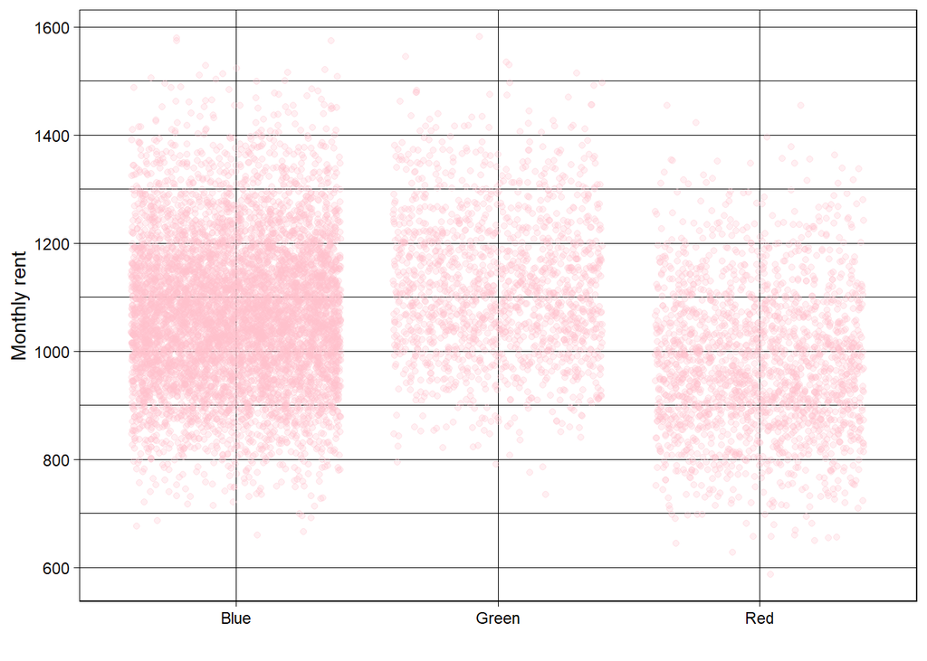

```r
ggplot(data) +
  geom_jitter(aes(x = color,
                 y = rent),
                 color = "pink",
                 alpha = 0.25) +
  scale_x_discrete(name = "") +
  scale_y_continuous(name = "Monthly rent") +
  theme_linedraw()
```

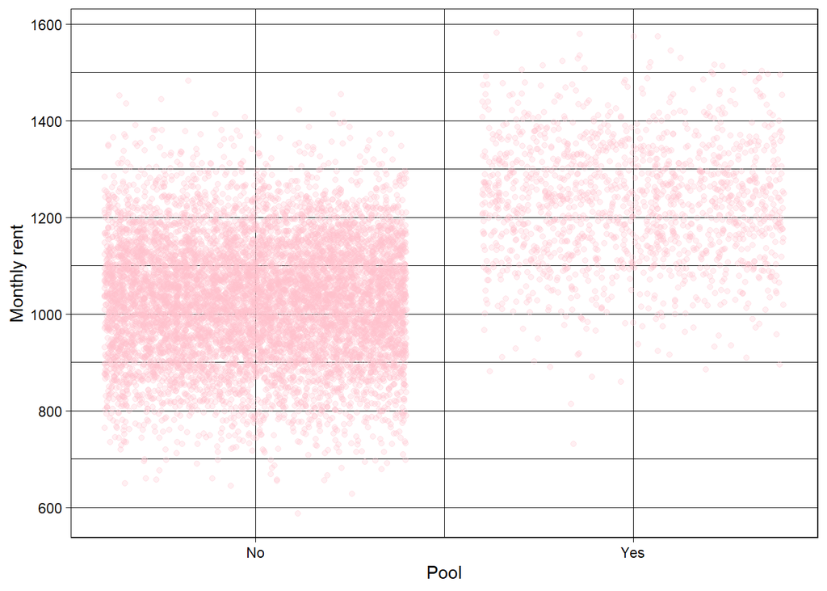

```r
ggplot(data) +
  geom_jitter(aes(x = pool,
                 y = rent),
                 color = "pink",
                 alpha = 0.25) +
  scale_x_continuous(name = "Pool",
                     breaks = c(0,1),
                     labels = c("No", "Yes")) +
  scale_y_continuous(name = "Monthly rent") +
  theme_linedraw()
```

# Data analysis

This section compares the observed data to the values used to generate the data.

## Descriptive statistics

The following table shows the descriptive statistics for the outcome variable.

```r
library(knitr)

summary_outcome <- data |>
  summarize(`Calculated average monthly rent` = mean(rent),
            `Calculated standard deviation of monthly rent` = sd(rent))

kable(summary_outcome,
      format.args = list(digits = 6))
```

| Calculated average monthly rent | Calculated standard deviation of monthly rent |
| --- | --- |
| 1058.48 | 140.262 |

The following table compares the average values of the continuous predictor variables to the values that were used to generate the data.

```r
mean_summary <- data |>
  pivot_longer(cols = c("sq_feet", "dt_dist"),
               names_to = "Variable",
               values_to = "value") |>
  group_by(Variable) |>
  summarize(`Calculated average` = mean(value)) |>
  mutate(`Input average` = case_when(Variable == "dt_dist" ~ dt_dist_mean,
                                     Variable == "sq_feet" ~ sq_feet_mean)) |>
  mutate(Variable = case_when(Variable == "dt_dist" ~
                                "Distance to downtown",
                              Variable == "sq_feet" ~
                                "Square footage")) |>
  mutate(Difference = `Input average` - `Calculated average`)

kable(mean_summary,
      format.args = list(digits = 3),
      align = c("l", "c", "c", "c"))
```

| Variable | Calculated average | Input average | Difference |
| --- | --- | --- | --- |
| Distance to downtown | 4.21 | 4.2 | -0.00618 |
| Square footage | 1501.58 | 1500.0 | -1.57544 |

The following table compares the standard deviations of the continuous predictor variables to the values that were used to generate the data.

```r
sd_summary <- data |>
  pivot_longer(cols = c("sq_feet", "dt_dist"),
               names_to = "Variable",
               values_to = "value") |>
  group_by(Variable) |>
  summarize(`Calculated standard deviation` = sd(value)) |>
  mutate(`Input standard deviation` =
           case_when(Variable == "dt_dist" ~ dt_dist_sd,
                     Variable == "sq_feet" ~ sq_feet_sd)) |>
  mutate(Variable = case_when(Variable == "dt_dist" ~
                                "Distance to downtown",
                              Variable == "sq_feet" ~
                                "Square footage")) |>
  mutate(Difference = `Input standard deviation` - `Calculated standard deviation`)

kable(sd_summary,
      format.args = list(digits = 3),
      align = c("l", "c", "c", "c"))
```

| Variable | Calculated standard deviation | Input standard deviation | Difference |
| --- | --- | --- | --- |
| Distance to downtown | 0.706 | 0.7 | -0.0061 |
| Square footage | 152.548 | 150.0 | -2.5484 |

The following table compares the proportions of the data in each color category to the proportions that were used to generate the data.

```r
color_summary <- tibble(Color = c("Red", "Blue", "Green"),
                        `Calculated proportion` = c(mean(data$color == "Red"),
                                                    mean(data$color == "Blue"),
                                                    mean(data$color == "Green")),
                        `Input proportion` = c(pct_red, pct_blue, pct_green)) |>
  mutate(Difference = `Input proportion` - `Calculated proportion`)

kable(color_summary)
```

| Color | Calculated proportion | Input proportion | Difference |
| --- | --- | --- | --- |
| Red | 0.1999 | 0.20 | 0.0001 |
| Blue | 0.6429 | 0.65 | 0.0071 |
| Green | 0.1572 | 0.15 | -0.0072 |

The following table compares the proportions of the data in each pool category to the proportions that were used to generate the data.

```r
pool_summary <- tibble(Color = c("Pool", "No pool"),
                        `Calculated proportion` = c(mean(data$pool),
                                                    1-mean(data$pool)),
                        `Input proportion` = c(pct_pool, pct_no_pool)) |>
  mutate(Difference = `Input proportion` - `Calculated proportion`)

kable(pool_summary)
```

| Color | Calculated proportion | Input proportion | Difference |
| --- | --- | --- | --- |
| Pool | 0.1491 | 0.15 | 9e-04 |
| No pool | 0.8509 | 0.85 | -9e-04 |

## Regression

The following table compares the regression coefficients to the values that were used to generate to outcome variable.

```r
model <- lm(rent ~
              sq_feet +
              dt_dist +
              blue +
              green +
              pool,
            data = data)

coeff_summary = tibble(Variable = names(input_coeffs),
                       `Input coefficients` = input_coeffs,
                       `Calculated coefficients` = model$coefficients) |>
  mutate(Difference = as.numeric(`Input coefficients`) -
           as.numeric(`Calculated coefficients`))

coeff_summary
```

```
## # A tibble: 6 × 4
##   Variable              `Input coefficients` Calculated coefficient…¹ Difference
##   <chr>                 <named list>                            <dbl>      <dbl>
## 1 Constant              <dbl [1]>                             100.      1.18e-11
## 2 Effect of square feet <dbl [1]>                               0.700  -7.88e-15
## 3 Effect of distance    <dbl [1]>                             -50.0    -7.11e-14
## 4 Effect of blue        <dbl [1]>                             100.      8.81e-13
## 5 Effect of green       <dbl [1]>                             150.      3.98e-13
## 6 Effect of pool        <dbl [1]>                             200.      4.55e-13
## # ℹ abbreviated name: ¹`Calculated coefficients`
```